# 金融数据分析quantmod作业1

rockchen26sh

2016-12-23

```r
library(quantmod)#加载包
```

```r
library(corrplot)
library(scales)
```

# 1)求出Apple公司在2013.1-2013.10的股票总成交量使用

```r
getSymbols("AAPL",SCR="yahoo",from="2013-01-01",to="2013-10-31")
```

[output not shown]

```
## [1] "AAPL"
```

```r
sum(Vo(AAPL))
```

```
## [1] 22534754200
```

# 2)找出这些股票暴涨暴跌的时间点（例如开盘价或收盘价比前一天涨跌幅度超过5%）

```r
options(digits=4)
getSymbols("AAPL")
```

```
## [1] "AAPL"
```

```r
getSymbols("MSFT")
```

```
## [1] "MSFT"
```

```r
getSymbols("ORCL")
```

```
## [1] "ORCL"
```

```r
getSymbols("GOOG")
```

```
## [1] "GOOG"
```

```r
AAPL_delt<- Delt(Ad(AAPL),type="arithmetic")#使用考虑到有拆股除权的情况，故使用调整价格
AAPL_up<- as.data.frame(AAPL_delt[which(AAPL_delt>0.05)])#涨幅超过5%的数据
AAPL_down<- as.data.frame(AAPL_delt[which(AAPL_delt< -0.05)])#跌幅超过5%的数据
AAPL_down<- cbind(row.names(AAPL_down),AAPL_down,"AAPL","down")
AAPL_up<- cbind(row.names(AAPL_up),AAPL_up,"AAPL","up")
colnames(AAPL_down)<- c("date","data","Company","updown")
colnames(AAPL_up)<- c("date","data","Company","updown")

MSFT_delt<- Delt(Ad(MSFT),type="arithmetic")#使用考虑到有拆股除权的情况，故使用调整价格
MSFT_up<- as.data.frame(MSFT_delt[which(MSFT_delt>0.05)])#涨幅超过5%的数据
MSFT_down<- as.data.frame(MSFT_delt[which(MSFT_delt< -0.05)])#跌幅超过5%的数据
MSFT_down<- cbind(row.names(MSFT_down),MSFT_down,"MSFT","down")
MSFT_up<- cbind(row.names(MSFT_up),MSFT_up,"MSFT","up")
colnames(MSFT_down)<- c("date","data","Company","updown")
colnames(MSFT_up)<- c("date","data","Company","updown")

ORCL_delt<- Delt(Ad(ORCL),type="arithmetic")#使用考虑到有拆股除权的情况，故使用调整价格
ORCL_up<- as.data.frame(ORCL_delt[which(ORCL_delt>0.05)])#涨幅超过5%的数据
ORCL_down<- as.data.frame(ORCL_delt[which(ORCL_delt< -0.05)])#跌幅超过5%的数据
ORCL_down<- cbind(row.names(ORCL_down),ORCL_down,"ORCL","down")
ORCL_up<- cbind(row.names(ORCL_up),ORCL_up,"ORCL","up")
colnames(ORCL_down)<- c("date","data","Company","updown")
colnames(ORCL_up)<- c("date","data","Company","updown")

GOOG_delt<- Delt(Ad(GOOG),type="arithmetic")#使用考虑到有拆股除权的情况，故使用调整价格
GOOG_up<- as.data.frame(GOOG_delt[which(GOOG_delt>0.05)])#涨幅超过5%的数据
GOOG_down<- as.data.frame(GOOG_delt[which(GOOG_delt< -0.05)])#跌幅超过5%的数据
GOOG_down<- cbind(row.names(GOOG_down),GOOG_down,"GOOG","down")
GOOG_up<- cbind(row.names(GOOG_up),GOOG_up,"GOOG","up")
colnames(GOOG_down)<- c("date","data","Company","updown")
colnames(GOOG_up)<- c("date","data","Company","updown")



Total<- rbind(AAPL_down,AAPL_up,MSFT_down,MSFT_up,ORCL_down,ORCL_up,GOOG_down,GOOG_up)
Total$date<-as.Date(Total$date)
Total<- Total[order(Total$date),]
Total$data<- percent(Total$data)
DT::datatable(Total,filter = 'top')
```

|  | date | data | Company | updown |
| --- | --- | --- | --- | --- |
| 2007-01-09 | 2007-01-09 | 8.3% | AAPL | up |
| 2007-01-18 | 2007-01-18 | -6.2% | AAPL | down |
| 2007-02-27 | 2007-02-27 | -5.2% | AAPL | down |
| 2007-07-20 | 2007-07-20 | -5.2% | GOOG | down |
| 2007-07-24 | 2007-07-24 | -6.1% | AAPL | down |
| 2007-07-26 | 2007-07-26 | 6.4% | AAPL | up |
| 2007-07-31 | 2007-07-31 | -6.8% | AAPL | down |
| 2007-08-09 | 2007-08-09 | -5.7% | AAPL | down |
| 2007-08-29 | 2007-08-29 | 5.7% | AAPL | up |
| 2007-09-05 | 2007-09-05 | -5.1% | AAPL | down |

[output cut: 225 more lines]

#通过搜索引擎寻找是什么原因导致这些暴涨暴跌，观察（或用程序分析）数据，看就暴涨暴跌事件是否有可以利用的买卖规律

1.苹果 2007/1/9 8.31% 第一代Iphone发布

2.苹果 2007/7/24 -6.13% AT&T发布最新财报，初代iPhone销量未达到逾期

3.苹果 2007/11/13 10.54% 中移动表示正在洽谈出售iPhone

4.苹果 2008/9/29 -17.92% “休伯蒂将苹果股价评级由“增持股份”(Overweight)下调至“持股观望”(Equal-weight)。美国众议院否决了对华尔街的救助计划”

5.苹果 2013/1/24 -12.36% 苹果利润未达预期

# 3)截取一段时间内这四家公司股价数据（注意分红派息除权对股价的影响），用R中的相关性分析判断股价之间的相关性，或者用R基础课程第八周所讲的MIC指标对其进行分析

```r
getSymbols("AAPL",from="2014-01-01",to="2016-12-01")
```

```
## [1] "AAPL"
```

```r
getSymbols("MSFT",from="2014-01-01",to="2016-12-01")
```

```
## [1] "MSFT"
```

```r
getSymbols("ORCL",from="2014-01-01",to="2016-12-01")
```

```
## [1] "ORCL"
```

```r
getSymbols("GOOG",from="2014-01-01",to="2016-12-01")
```

```
## [1] "GOOG"
```

```r
total_ad<- data.frame(Ad(AAPL),Ad(MSFT),Ad(ORCL),Ad(GOOG))
cor(total_ad)
```

```
##               AAPL.Adjusted MSFT.Adjusted ORCL.Adjusted GOOG.Adjusted
## AAPL.Adjusted        1.0000       0.44470       0.47527        0.1153
## MSFT.Adjusted        0.4447       1.00000       0.05617        0.8548
## ORCL.Adjusted        0.4753       0.05617       1.00000       -0.2666
## GOOG.Adjusted        0.1153       0.85482      -0.26656        1.0000
```

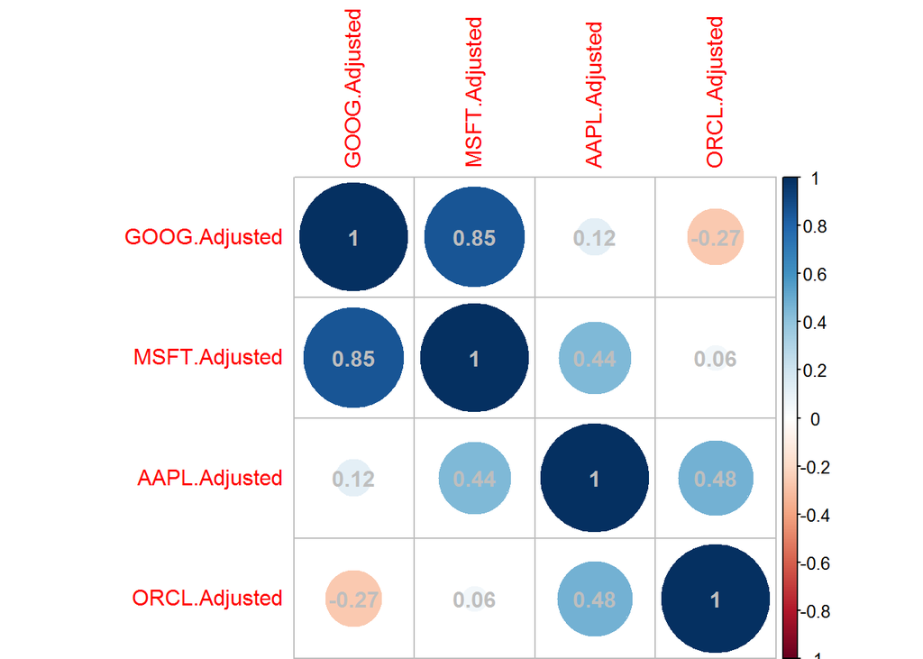

```r
corrplot(cor(total_ad),order='AOE',addCoef.col = "grey")
```

```r
 #相关性分析图表展现
```